# simon-5501-12-slides

2026-11-10

## Topics to be covered

- What you will learn
  - Two factor analysis of variance
  - Relationship to linear regression
  - Checking assumptions
  - R code for two factor analysis of variance
  - Interactions
  - R code for interactions
  - Your homework

## Two factor analysis of variance

- Continuous outcome
- Two categorical predictors
- Example
  - Hearing test (decibels at high frequency)
  - Age group (Old or Young)
  - Gender (Female or Male)

## Balanced data

- Proportional number in each category level combination group
  - 3 old females, 3 old males, 3 young females, 3 young males
  - 6 old females, 6 old males, 2 young females, 2 young males

## Unbalanced data

- Unequal numbers in some category combinations
  - 2 old females, 4 old males, 3 young females, 2 young males
- Extreme case: empty category combinations
  - 3 old females, 3 old males, 3 young females, 0 young males

## Historical perspective on unbalanced data, 1

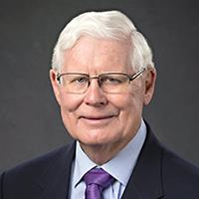

## Historical perspective on unbalanced data, 2

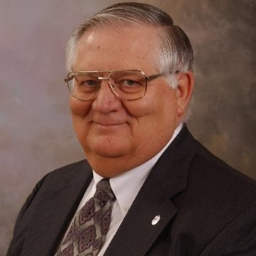

## Historical perspective on unbalanced data, 3

[figure not shown]

## Historical perspective on unbalanced data, 4

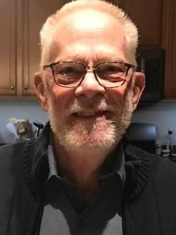

## A simple illustration of the complexities of unbalanced data, 1

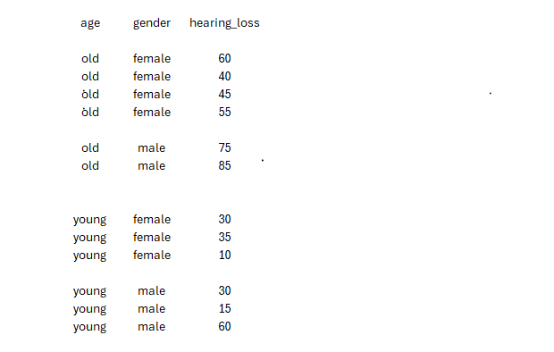

## A simple illustration of the complexities of unbalanced data, 2

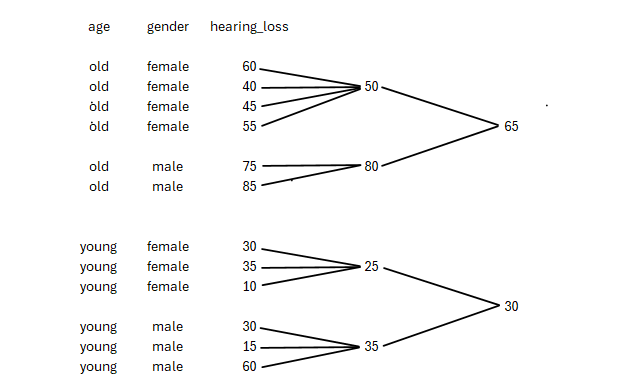

## A simple illustration of the complexities of unbalanced data, 3

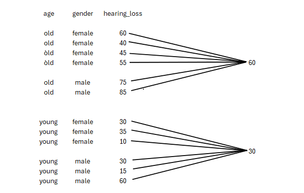

## Mathematical model, 1

- $Y_{ijk}$
  - i = which level of first category
  - j = which level of second category
  - k = which patient within a category combination

## Mathematical model, 2

$\begin{smallmatrix} Age & Gender & Outcome \\ Old & Female & Y_{111} \\ Old & Female & Y_{112} \\ Old & Female & Y_{113} \\ Old & Male & Y_{121} \\ Old & Male & Y_{122} \\ Old & Male & Y_{123} \\ Young & Female & Y_{211} \\ Young & Female & Y_{212} \\ Young & Female & Y_{213} \\ Young & Male & Y_{221} \\ Young & Male & Y_{222} \\ Young & Male & Y_{223}\end{smallmatrix}$

## Mathematical model, 3

- $Y_{ijk} = \mu + \alpha_i + \beta_j +\epsilon_{ijk}$
  - $i=1,...,a,\ j=1,...,b$
  - $\Sigma \alpha_i=0,\ \Sigma \beta_j=0$
  - $\epsilon_{ijk}$ is $N(0,\sigma)$
- $\bar{Y}_{i..}$ is the average for the ith level of first factor
- $\bar{Y}_{.j.}$ is the average for the jth level of second factor
- $\bar{Y}_{...}$ is the average for all of the data

## Mathematical model, 4

- $SS(Total)=\Sigma_i \Sigma_j \Sigma_k\ (Y_{ijk}-\bar{Y}_{...})^2$
  - df=abn-1
- $SS(A)=\Sigma_i\ bn(\bar{Y}_{i..}-\bar{Y}_{...})^2$
  - df=a-1
- $SS(B)=\Sigma_j\ an(\bar{Y}_{.j.}-\bar{Y}_{...})^2$
  - df=b-1
- $SS(Error)=SS(Total)-SS(A)-SS(B)$
  - df=(abn-1)-(a-1)-(b-1)

## Use of indicator variables

$\begin{smallmatrix} Age & Gender & Outcome & iYoung & iMale \\ Old & Female & Y_{111} & 0 & 0 \\ Old & Female & Y_{112} & 0 & 0 \\\ Old & Female & Y_{113} & 0 & 0 \\\ Old & Male & Y_{121} & 0 & 1 \\\ Old & Male & Y_{122} & 0 & 1 \\ Old & Male & Y_{123} & 0 & 1 \\ Young & Female & Y_{211} & 1 & 0 \\ Young & Female & Y_{212} & 1 & 0 \\ Young & Female & Y_{213} & 1 & 0 \\ Young & Male & Y_{221} & 1 & 1 \\ Young & Male & Y_{222} & 1 & 1 \\ Young & Male & Y_{223}& 1 & 1 \end{smallmatrix}$

## Interpretation of coefficients

- Intercept
  - Estimated average value at two reference levels (Old, Female)
- Slope for age
  - Estimated average change when you switch from Old to Young
  - Holding gender constant
- Slope for gender
  - Estimated average change when you switch from female to male
  - Holding age constant

## Break #1

- What you have learned
  - Two factor analysis of variance
- What’s coming next
  - Relationship to linear regression

## Hypothetical hearing loss data

```
# A tibble: 12 × 4
   age   gender code     db
   <chr> <chr>  <chr> <dbl>
 1 old   female of       45
 2 old   female of       60
 3 old   female of       60
 4 old   male   om       65
 5 old   male   om       60
 6 old   male   om       70
 7 young female yf       20
 8 young female yf       20
 9 young female yf        5
10 young male   ym       25
11 young male   ym       20
12 young male   ym       30
```

## Create indicator variables

```
# A tibble: 12 × 6
   age   gender code  i_young i_male    db
   <chr> <chr>  <chr>   <dbl>  <dbl> <dbl>
 1 old   female of          0      0    45
 2 old   female of          0      0    60
 3 old   female of          0      0    60
 4 old   male   om          0      1    65
 5 old   male   om          0      1    60
 6 old   male   om          0      1    70
 7 young female yf          1      0    20
 8 young female yf          1      0    20
 9 young female yf          1      0     5
10 young male   ym          1      1    25
11 young male   ym          1      1    20
12 young male   ym          1      1    30
```

## Means by age and gender

```
# A tibble: 4 × 3
# Groups:   age [2]
  age   gender cell_mean
  <chr> <chr>      <dbl>
1 old   female        55
2 old   male          65
3 young female        15
4 young male          25
```

```
# A tibble: 2 × 2
  age   age_mean
  <chr>    <dbl>
1 old         60
2 young       20
```

```
# A tibble: 2 × 2
  gender gender_mean
  <chr>        <dbl>
1 female          35
2 male            45
```

## Two factor analysis of variance using aov

```
Analysis of Variance Table

Response: db
          Df Sum Sq Mean Sq F value    Pr(>F)
age        1   4800  4800.0  108.00 2.595e-06 ***
gender     1    300   300.0    6.75   0.02883 *
Residuals  9    400    44.4
---
Signif. codes:  0 '***' 0.001 '**' 0.01 '*' 0.05 '.' 0.1 ' ' 1
```

## Two factor analysis of variance using linear regression, 2

```r
tidy(m1)
```

```
# A tibble: 3 × 5
  term        estimate std.error statistic      p.value
  <chr>          <dbl>     <dbl>     <dbl>        <dbl>
1 (Intercept)     55        3.33     16.5  0.0000000492
2 ageyoung       -40        3.85    -10.4  0.00000260
3 gendermale      10.0      3.85      2.60 0.0288
```

## Graphical display of the data

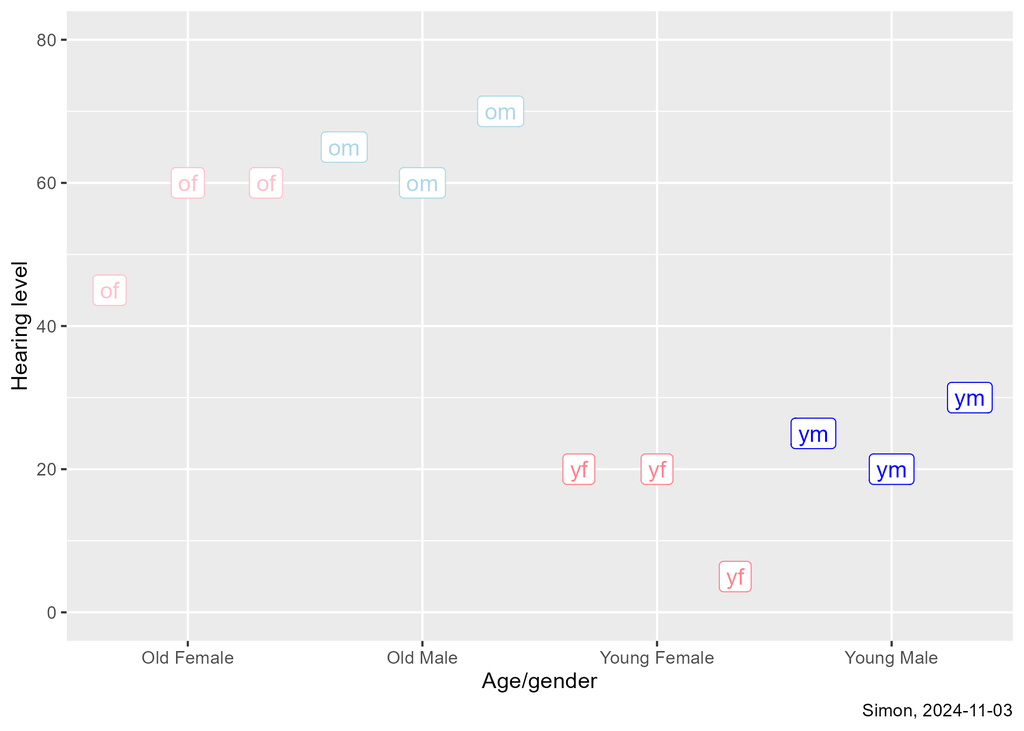

## Computation of SS(total)

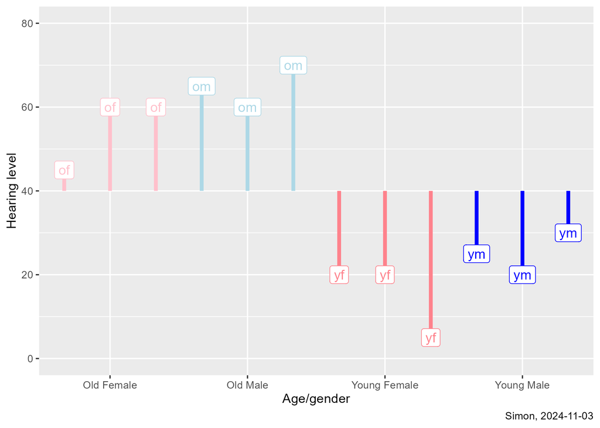

## Computation of SS(age)

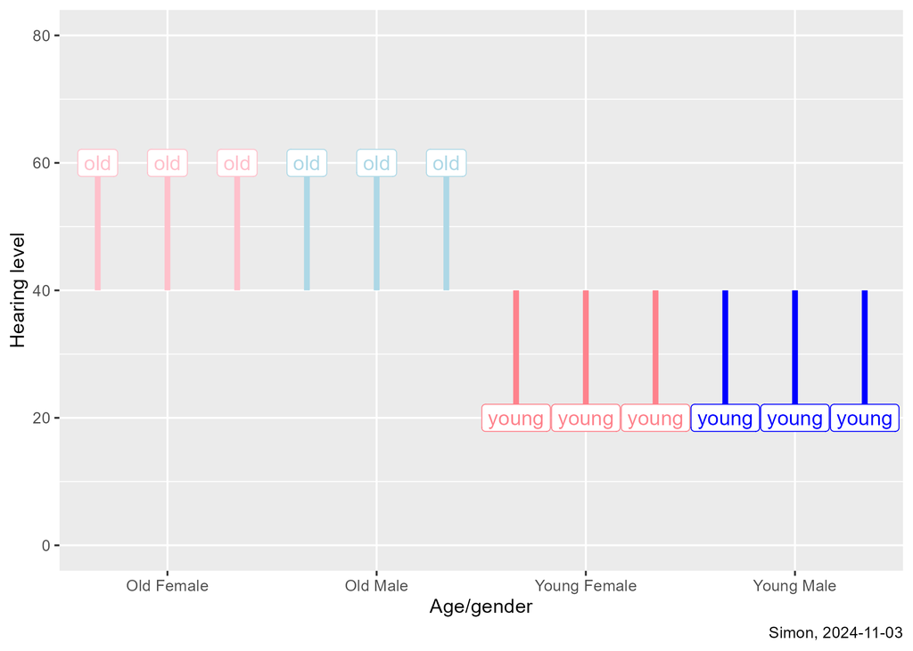

## Computation of SS(gender)

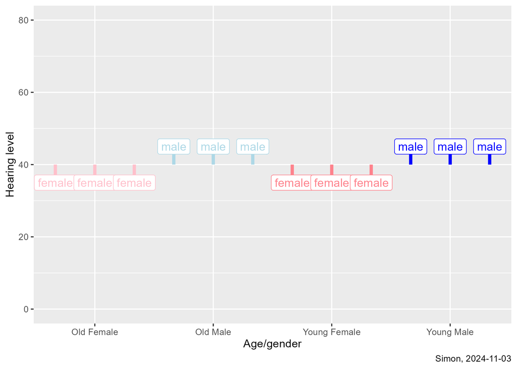

## Break #2

- What you have learned
  - Relationship to linear regression
- What’s coming next
  - Checking assumptions

## Checking assumptions

- Normality (Non-normality)
- Homogeneity (Heterogeneity)
- Independence (Lack of independence)
- Do not check for linearity (non-linearity)

## Use the boxplot to check assumptions

- Boxplots or residual plots
  - Look for skewness and/or outliers
  - Look for large change in variation
- Independence is checked qualitatively

## Alternatives if assumptions violated

- There is no analog to Kruskal-Wallis or Mann-Whitney-Wilcoxon
- Consider a log transformation
  - All values greater than 0
  - Groups with larger means have larger variation
  - Data is skewed right and outliers only on the high end

## Break #3

- What you have learned
  - Checking assumptions
- What’s coming next
  - R code for two factor analysis of variance

## Part 1, analysis of moon data

Find the file simon-5501-12-demo.qmd on my github site. We will cover part 1 in this lecture.

## Break #4

- What you have learned
  - R code for two factor analysis of variance
- What’s coming next
  - Interactions

## What is an interaction

- Impact of one variable is influenced by a second variable
- Example, influence of alcohol on sleeping pills
- Three types of interactions
  - Between two categorical predictors
  - Between a categorical and a continuous predictor
  - Between two continuous predictors
- Interactions greatly complicate interpretation

## Interaction plot

- X axis, first categorical variable
- Separate lines for second categorical variable
- Y axis, average outcome
  - Ambiguity in “first” and “second”
  - Try it both ways?

## Hypothetical interaction plots, 1

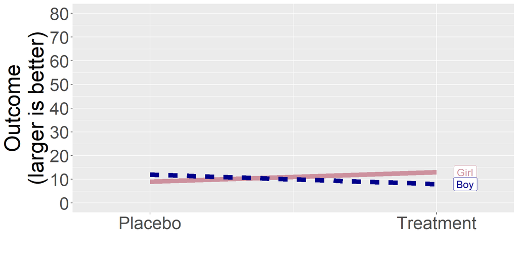

- No interaction
- Ineffective treatment
- Boys/girls similar

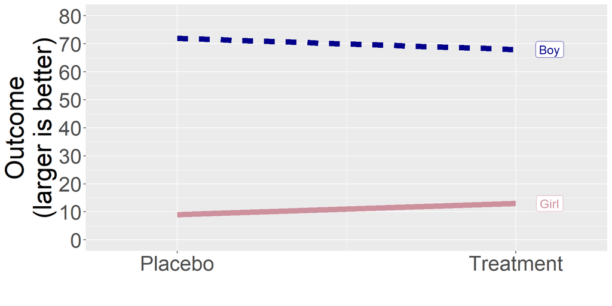

- No interaction
- Ineffective treatment
- Boys fare better than girls

## Hypothetical interaction plots, 2

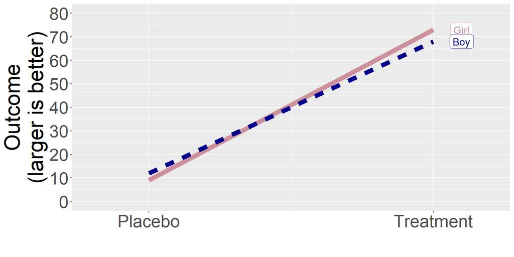

- No interaction
- Effective treatment
- Boys/girls similar

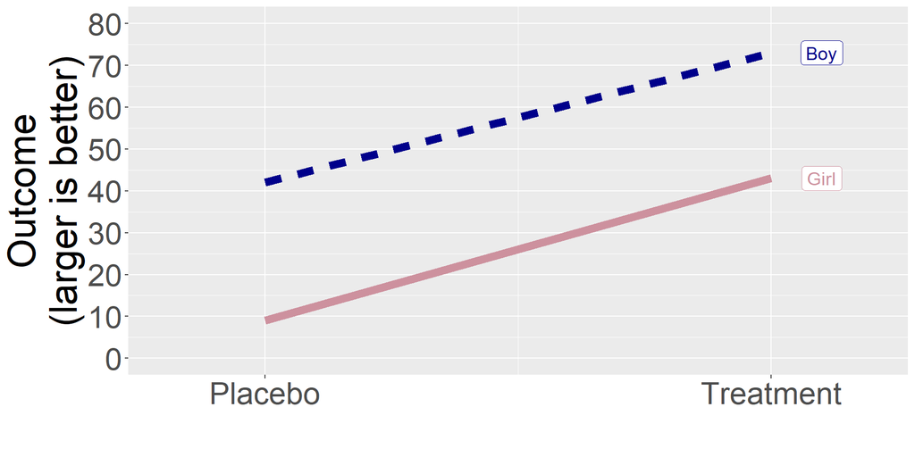

- No interaction
- Effective treatment
- Boys fare better than girls

## Hypothetical interaction plots, 3

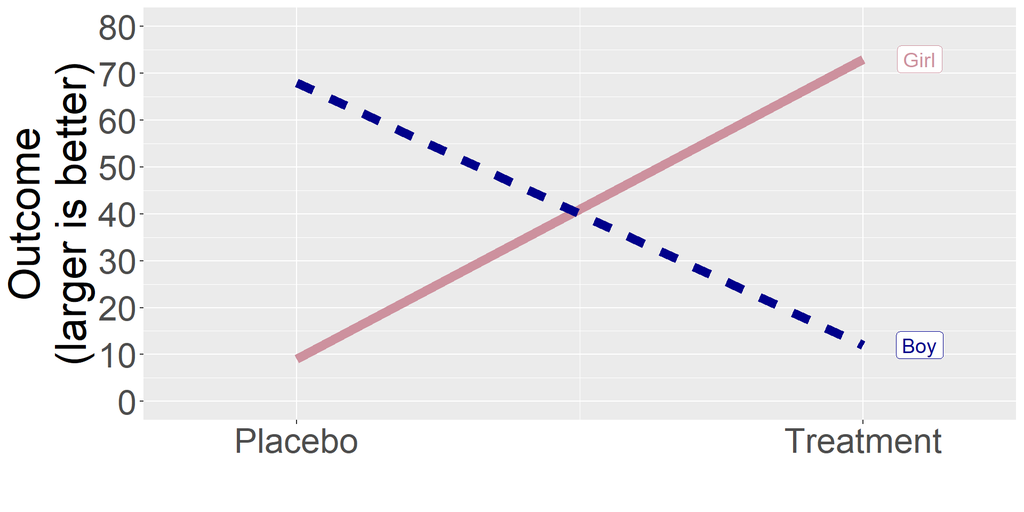

- Significant interaction
- Harmful treatment in boys
- Effective treatment in girls

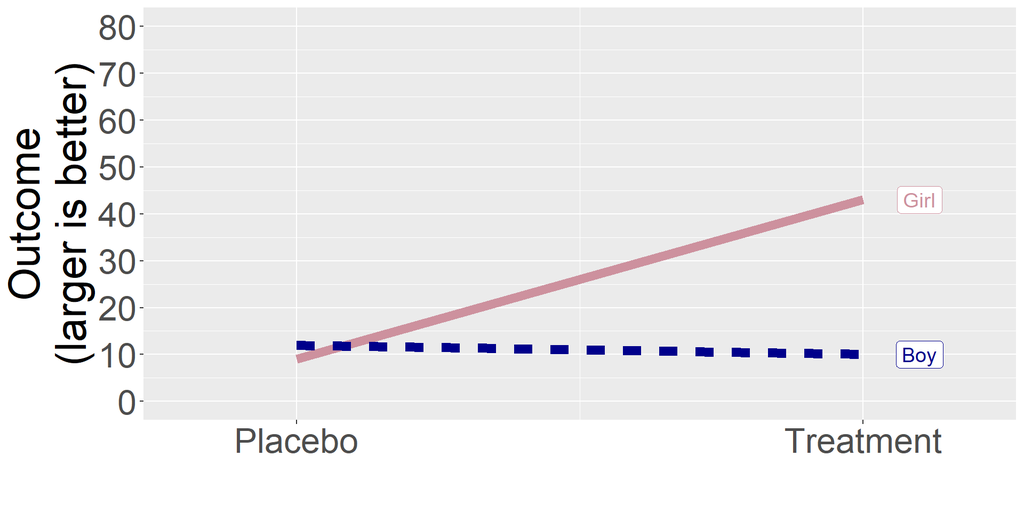

- Significant interaction
- Ineffective treatment in boys
- Effective treatment in girls

## Hypothetical interaction plots, 4

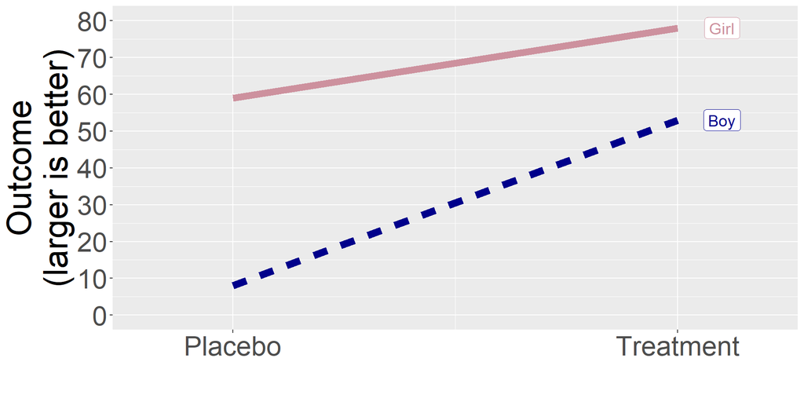

- Significant interaction
- Girls fare better overall
- Effective treatment
- Much more effective in boys

## Indicator variable for an interaction

```
# A tibble: 12 × 7
   age   gender code  i_young i_male i_m_by_y    db
   <chr> <chr>  <chr>   <dbl>  <dbl>    <dbl> <dbl>
 1 old   female of          0      0        0    45
 2 old   female of          0      0        0    60
 3 old   female of          0      0        0    60
 4 old   male   om          0      1        0    65
 5 old   male   om          0      1        0    60
 6 old   male   om          0      1        0    70
 7 young female yf          1      0        0    20
 8 young female yf          1      0        0    20
 9 young female yf          1      0        0     5
10 young male   ym          1      1        1    25
11 young male   ym          1      1        1    20
12 young male   ym          1      1        1    30
```

## Interpretation of intercept and slopes

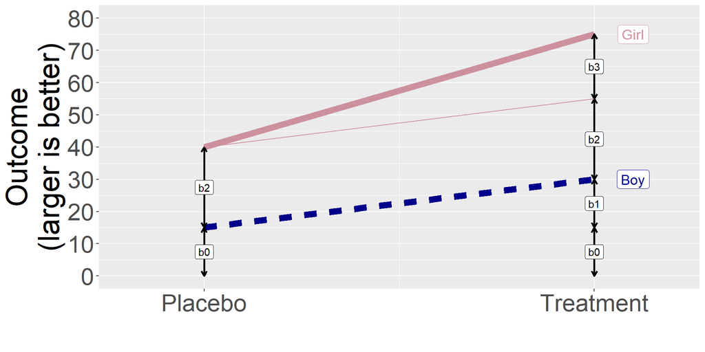

## When you can’t estimate an interaction

- Special case, n=1
  - Only one observation for categorical combination

## Example, full moon study, 1 of 2

```
# A tibble: 36 × 3
   month1 moon1      n
   <fct>  <fct>  <int>
 1 Aug    Before     1
 2 Aug    During     1
 3 Aug    After      1
 4 Sep    Before     1
 5 Sep    During     1
 6 Sep    After      1
 7 Oct    Before     1
 8 Oct    During     1
 9 Oct    After      1
10 Nov    Before     1
# ℹ 26 more rows
```

## Example, full moon study, 2 of 2

```r
m1 <- aov(admission ~ month*moon, data=er)
anova(m1)
```

```
Analysis of Variance Table

Response: admission
           Df Sum Sq Mean Sq F value Pr(>F)
month      11 455.58  41.417     NaN    NaN
moon        2  41.51  20.757     NaN    NaN
month:moon 22 127.82   5.810     NaN    NaN
Residuals   0   0.00     NaN
```

## Break #5

- What you have learned
  - Interactions
- What’s coming next
  - R code for interactions

## Analysis of fruitfly data

Find the file simon-5501-12-demo.qmd. We will cover part 2 in this lecture.

## Break #6

- What you have learned
  - R code for interactions
- What’s coming next
  - Your homework

## Your homework

Find the file simon-5501-12-directions.md on my github site.

## Summary

- What you have learned
  - Two factor analysis of variance
  - Relationship to linear regression
  - Checking assumptions
  - R code for two factor analysis of variance
  - Interactions
  - R code for interactions
  - Your homework